# Business Statistics End of Term Assessment IB94X0

## Calculate average daily sales and average total reviews by genre

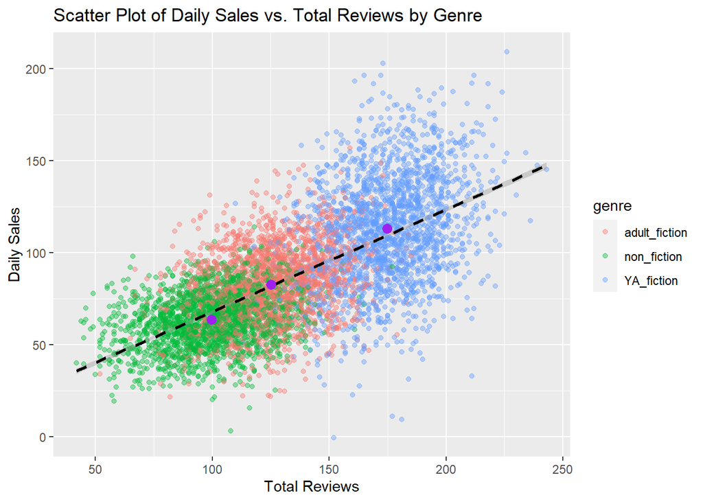

```r
average_stats <- dataset_publisher %>%
  group_by(genre) %>%
  dplyr::summarize(avg_daily_sales = mean(daily.sales),
            avg_total_reviews = mean(total.reviews))

# Scatter plot with points for average values
ggplot(dataset_publisher, aes(x = total.reviews, y = daily.sales, color = genre)) +
  geom_point(alpha = 0.4) +
  geom_smooth(method = "glm", color = "black", linetype = "dashed") +
  geom_point(data = average_stats, aes(x = avg_total_reviews, y = avg_daily_sales),
             color="purple", size = 3) +
  labs(title = "Scatter Plot of Daily Sales vs. Total Reviews by Genre",
       x = "Total Reviews",
       y = "Daily Sales")
```

We can clearly see that the non fiction have less review on average and in comparison less daily sale on average and adult fiction have more total reviews on average and hence more daily sales and at last , on average the YA-fiction have the most total reviews on average and hence most daily sales on average .The purple dots indicate the average daily sales vs avearage total reviews for each genre

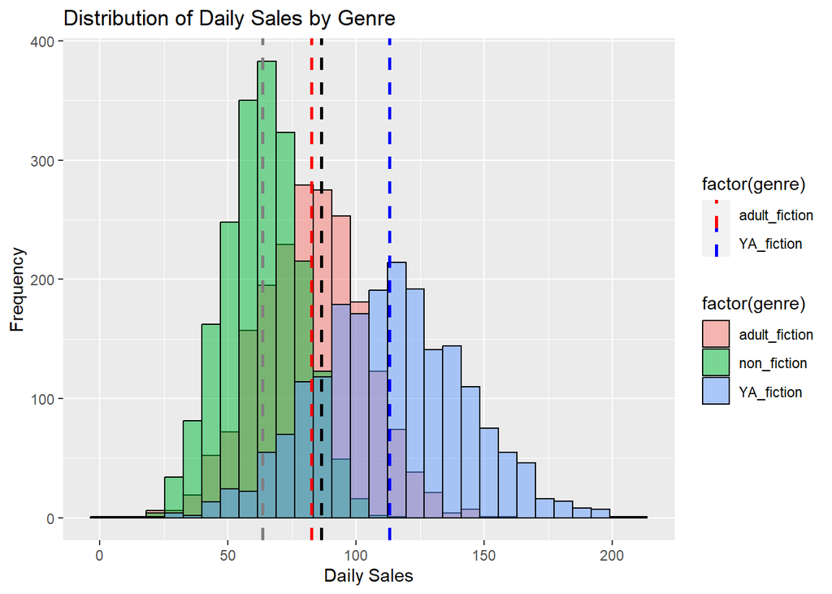

```r
ggplot(dataset_publisher, aes(x = daily.sales, fill = factor(genre))) +
  geom_histogram(alpha = 0.5, bins = 30, color = "black", position = "identity") +
  geom_vline(data = dataset_publisher %>%
               group_by(genre) %>%
               dplyr::summarize(mean_daily_sales = mean(daily.sales, na.rm = TRUE)),
             aes(xintercept = mean_daily_sales, color = factor(genre)),
             linetype = "dashed", linewidth = 1) + geom_vline(xintercept = mean(dataset_publisher$daily.sales), linetype = "dashed", color = "black", linewidth = 1)+
  scale_color_manual(values = c("adult_fiction" = "red", "YA_fiction" = "blue", "non_fiction-Fi" = "green")) +
  labs(title = "Distribution of Daily Sales by Genre",
       x = "Daily Sales",
       y = "Frequency")
```

The graph shows that the non-fiction and YA-fiction have very difference in mean daily sales as compared to the adult-fiction which has similar daily sales as of whole dataset

```r
#checking the corrrelation between the different attributes with daily sales
(cor_matrix<-rcorr(as.matrix(select_if(dataset_publisher,is.numeric))))
```

```
##               avg.review daily.sales total.reviews sale.price
## avg.review          1.00       -0.02         -0.01       0.00
## daily.sales        -0.02        1.00          0.68      -0.51
## total.reviews      -0.01        0.68          1.00      -0.55
## sale.price          0.00       -0.51         -0.55       1.00
##
## n= 5977
##
##
## P
##               avg.review daily.sales total.reviews sale.price
## avg.review               0.1934      0.3806        0.7310
## daily.sales   0.1934                 0.0000        0.0000
## total.reviews 0.3806     0.0000                    0.0000
## sale.price    0.7310     0.0000      0.0000
```

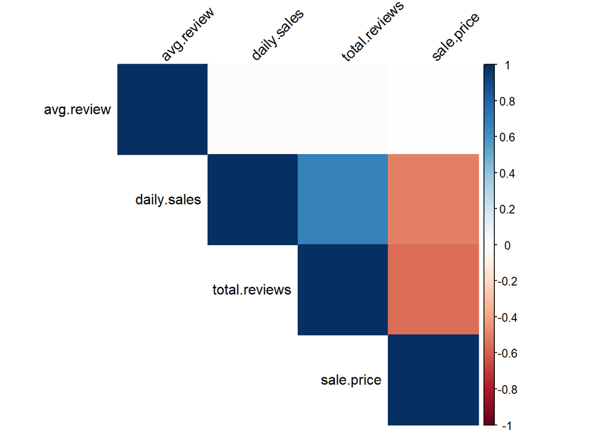

```r
corrplot(cor_matrix$r, method = "color", type = "upper", tl.col = "black", tl.srt = 45)
```

We can clearly interpret there is a weak negative correlation between average review and daily sales.Total reviews exhibit a moderate positive correlation with daily sales, while sale price shows a moderate negative correlation.

## Now checking the correlation for different genre

```r
dataset_publisher_non_fiction <- dataset_publisher %>%
  filter(genre == "non_fiction")
dataset_publisher_YA_fiction <- dataset_publisher %>%
  filter(genre == "YA_fiction")
dataset_publisher_adult_fiction <- dataset_publisher %>%
  filter(genre == "adult_fiction")
```

```r
#for non fiction
(cor_matrix1<-rcorr(as.matrix(select_if(dataset_publisher_non_fiction,is.numeric))))
```

```
##               avg.review daily.sales total.reviews sale.price
## avg.review          1.00        0.01          0.01      -0.02
## daily.sales         0.01        1.00          0.31      -0.01
## total.reviews       0.01        0.31          1.00      -0.01
## sale.price         -0.02       -0.01         -0.01       1.00
##
## n= 1993
##
##
## P
##               avg.review daily.sales total.reviews sale.price
## avg.review               0.6555      0.8093        0.3067
## daily.sales   0.6555                 0.0000        0.6731
## total.reviews 0.8093     0.0000                    0.7873
## sale.price    0.3067     0.6731      0.7873
```

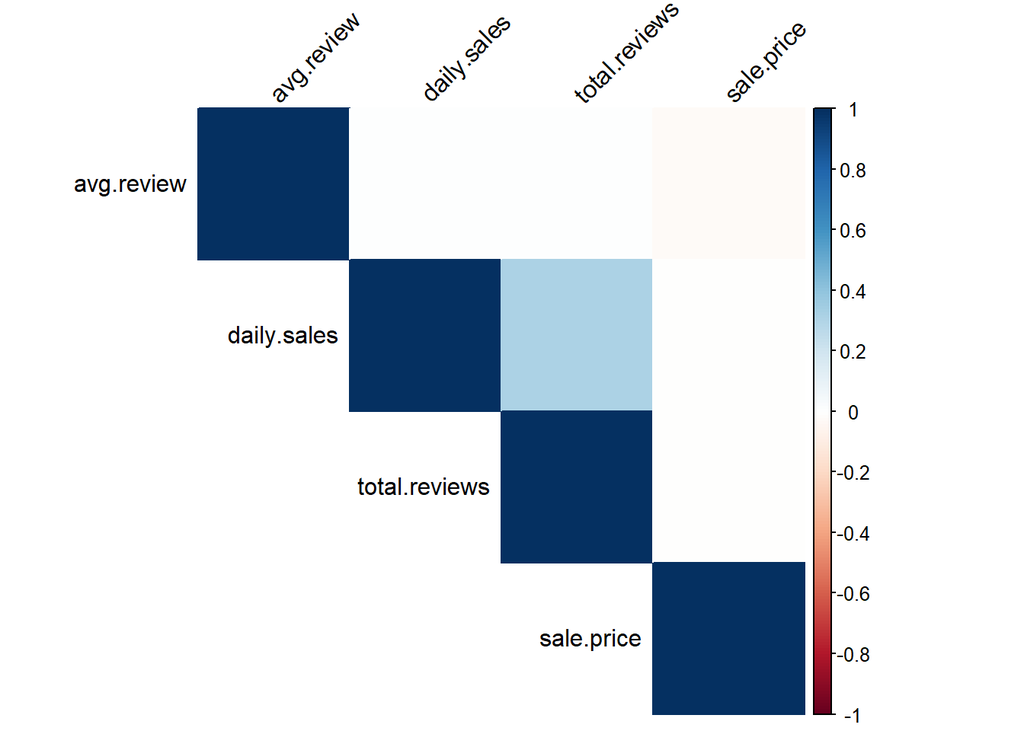

```r
corrplot(cor_matrix1$r, method = "color", type = "upper", tl.col = "black", tl.srt = 45)
```

For Non-fiction the correlation between daily sales and average review and sale price is negligible whereas the total reviews have some positive correlation with daily sales

```r
#for YA fiction
(cor_matrix2<-rcorr(as.matrix(select_if(dataset_publisher_YA_fiction,is.numeric))))
```

```
##               avg.review daily.sales total.reviews sale.price
## avg.review          1.00       -0.01          0.01       0.03
## daily.sales        -0.01        1.00          0.28      -0.24
## total.reviews       0.01        0.28          1.00       0.00
## sale.price          0.03       -0.24          0.00       1.00
##
## n= 1991
##
##
## P
##               avg.review daily.sales total.reviews sale.price
## avg.review               0.6849      0.5493        0.1514
## daily.sales   0.6849                 0.0000        0.0000
## total.reviews 0.5493     0.0000                    0.8590
## sale.price    0.1514     0.0000      0.8590
```

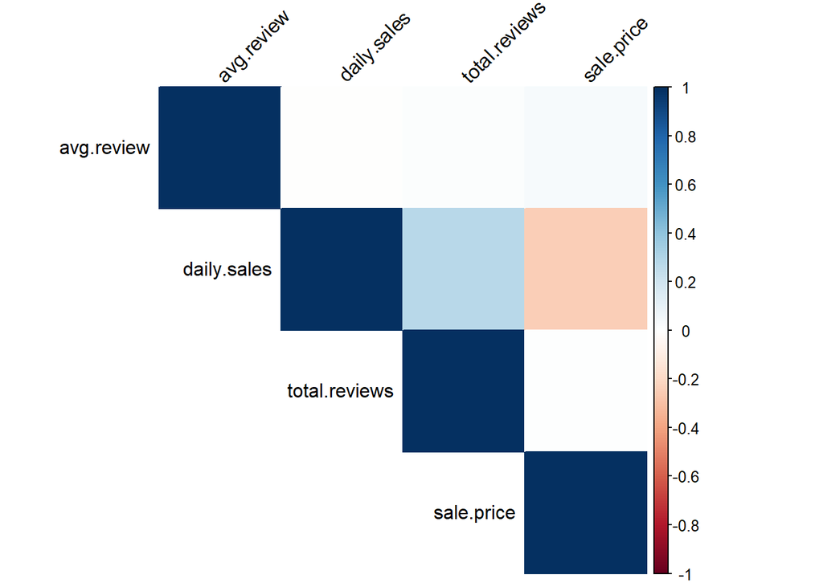

```r
corrplot(cor_matrix2$r, method = "color", type = "upper", tl.col = "black", tl.srt = 45)
```

For YA-fiction there is negligible correlation between average sales and sale price whereas total reviews has positive correlation and sales price has negative correlation

```r
#for adult fiction
(cor_matrix3<-rcorr(as.matrix(select_if(dataset_publisher_adult_fiction,is.numeric))))
```

```
##               avg.review daily.sales total.reviews sale.price
## avg.review          1.00       -0.01          0.01      -0.02
## daily.sales        -0.01        1.00          0.29      -0.07
## total.reviews       0.01        0.29          1.00       0.01
## sale.price         -0.02       -0.07          0.01       1.00
##
## n= 1993
##
##
## P
##               avg.review daily.sales total.reviews sale.price
## avg.review               0.6127      0.6242        0.4504
## daily.sales   0.6127                 0.0000        0.0023
## total.reviews 0.6242     0.0000                    0.7840
## sale.price    0.4504     0.0023      0.7840
```

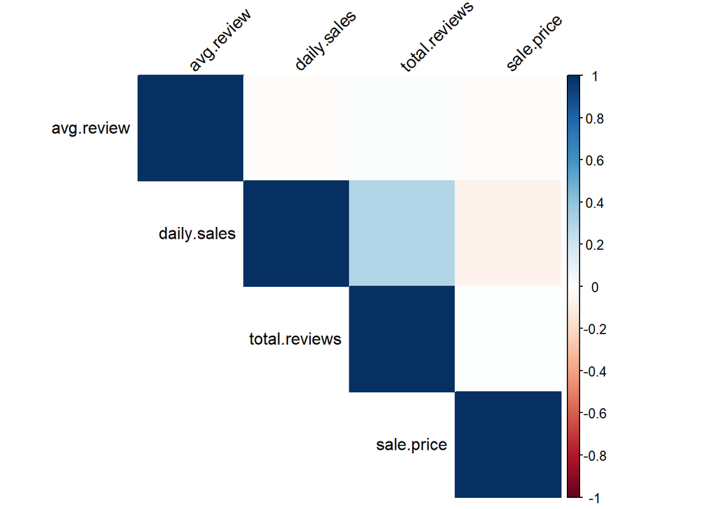

```r
corrplot(cor_matrix3$r, method = "color", type = "upper", tl.col = "black", tl.srt = 45)
```

For adult-fiction the correlation between average sales and daily price has negligible correlation whereas there is a positive correlation between total reviews and daily sales and some negative correlation between sale price and daily sales

```r
plot1<-ggplot(dataset_publisher,aes(x=total.reviews,y=daily.sales))+geom_point(aes(color=genre),alpha=0.5)+geom_smooth(method=glm,aes(group=genre,color=genre)) + geom_smooth(method=glm,color="black",linetype = "dashed")+labs(title = "Scatter Plot of Daily Sales vs. Total Reviews by Genre",
       x = "Total Reviews",
       y = "Daily Sales")
```

```r
plot2<-ggplot(dataset_publisher,aes(x=avg.review,y=daily.sales))+geom_point(aes(color=genre),alpha=0.5)+geom_smooth(method=glm,aes(group=genre,color=genre)) + geom_smooth(method=glm,color="black",linetype = "dashed")+labs(title = "Scatter Plot of Daily Sales vs. Average Reviews by Genre",
       x = "Average Reviews",
       y = "Daily Sales")
```

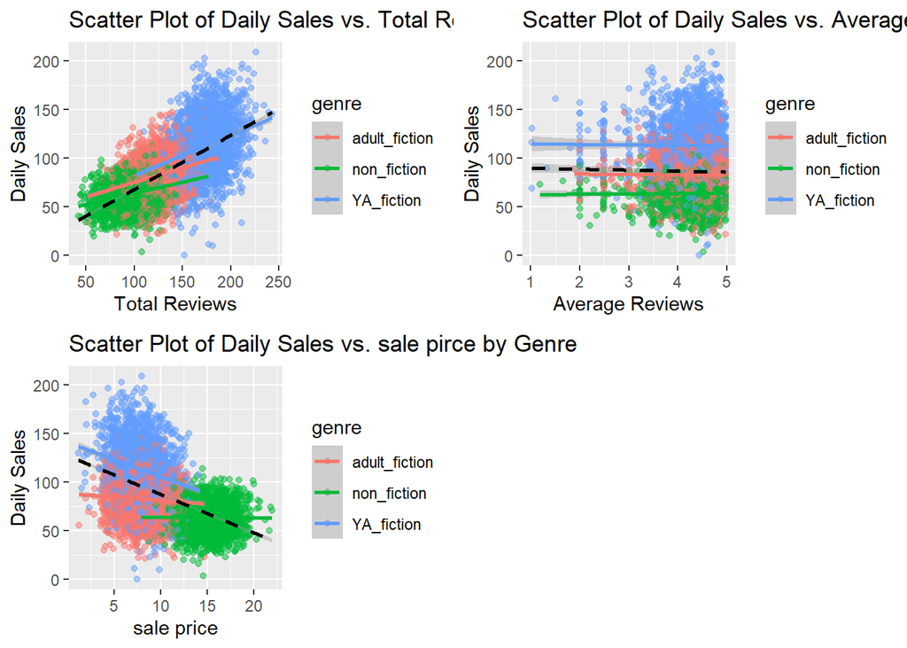

```r
plot3<-ggplot(dataset_publisher,aes(x=sale.price,y=daily.sales))+geom_point(aes(color=genre),alpha=0.5)+geom_smooth(method=glm,aes(group=genre,color=genre)) + geom_smooth(method=glm,color="black",linetype = "dashed")+labs(title = "Scatter Plot of Daily Sales vs. sale pirce by Genre",
       x = "sale price",
       y = "Daily Sales")

grid.arrange(plot1,plot2,plot3,ncol=2)
```

we can clearly see that sale price and total reviews have effect in our daily sales across genre whereas Average reviews does not have a significant effect on our daily sales and the correlation results that were found above can be easily seen from these graphs

## Making Lm models

### Model for the avg review and total reviews

```r
publisher_lm<-lm(daily.sales ~ avg.review+ total.reviews, data = dataset_publisher)
publisher_lm2<-lm(daily.sales ~ avg.review*total.reviews, data = dataset_publisher)
```

### Checking summary for the models

```r
summary(publisher_lm)
```

```
##
## Call:
## lm(formula = daily.sales ~ avg.review + total.reviews, data = dataset_publisher)
##
## Residuals:
##      Min       1Q   Median       3Q      Max
## -103.558  -14.428   -0.656   13.603   94.463
##
## Coefficients:
##                Estimate Std. Error t value Pr(>|t|)
## (Intercept)   14.679856   2.673978   5.490 4.19e-08 ***
## avg.review    -0.546363   0.568776  -0.961    0.337
## total.reviews  0.555669   0.007762  71.587  < 2e-16 ***
## ---
## Signif. codes:  0 '***' 0.001 '**' 0.01 '*' 0.05 '.' 0.1 ' ' 1
##
## Residual standard error: 22.17 on 5974 degrees of freedom
## Multiple R-squared:  0.4619, Adjusted R-squared:  0.4617
## F-statistic:  2564 on 2 and 5974 DF,  p-value: < 2.2e-16
```

```r
# The intercept is estimated at 14.68 (p < 0.001), indicating the expected 'daily.sales' when both predictors are zero. 'avg.review' is not statistically significant (p = 0.337), suggesting it may not contribute significantly to predicting 'daily.sales.' Conversely, 'total.reviews' is highly significant (p < 0.001) with a positive coefficient of 0.556, implying a substantial positive impact on 'daily.sales.' The model has an overall explanatory power (R-squared) of 46.19%, suggesting it captures a notable portion of the variance in 'daily.sales.' The F-statistic (2564, p < 0.001) indicates the model's overall significance.

summary(publisher_lm2)
```

```
##
## Call:
## lm(formula = daily.sales ~ avg.review * total.reviews, data = dataset_publisher)
##
## Residuals:
##      Min       1Q   Median       3Q      Max
## -103.512  -14.426   -0.661   13.609   94.475
##
## Coefficients:
##                           Estimate Std. Error t value Pr(>|t|)
## (Intercept)              12.693671   9.330833   1.360    0.174
## avg.review               -0.083117   2.161175  -0.038    0.969
## total.reviews             0.570148   0.065627   8.688   <2e-16 ***
## avg.review:total.reviews -0.003378   0.015205  -0.222    0.824
## ---
## Signif. codes:  0 '***' 0.001 '**' 0.01 '*' 0.05 '.' 0.1 ' ' 1
##
## Residual standard error: 22.18 on 5973 degrees of freedom
## Multiple R-squared:  0.4619, Adjusted R-squared:  0.4616
## F-statistic:  1709 on 3 and 5973 DF,  p-value: < 2.2e-16
```

```r
#The intercept is estimated at 12.69 (p = 0.174), representing the expected 'daily.sales' when both predictors are zero. 'avg.review' and its interaction with 'total.reviews' are not statistically significant (p = 0.969 and p = 0.824, respectively), suggesting that these terms may not contribute significantly to predicting 'daily.sales.' On the other hand, 'total.reviews' remains highly significant (p < 0.001) with a positive coefficient of 0.570, indicating a substantial positive impact on 'daily.sales.' The model's overall explanatory power (R-squared) remains at 46.19%, and the F-statistic (1709, p < 0.001) indicates the model's overall significance.
```

##### Performing anova test

```r
anova(publisher_lm,publisher_lm2)
```

```
## Analysis of Variance Table
##
## Model 1: daily.sales ~ avg.review + total.reviews
## Model 2: daily.sales ~ avg.review * total.reviews
##   Res.Df     RSS Df Sum of Sq      F Pr(>F)
## 1   5974 2937485
## 2   5973 2937461  1    24.277 0.0494 0.8242
```

```r
vif(publisher_lm)
```

```
##    avg.review total.reviews
##      1.000129      1.000129
```

```r
vif(publisher_lm2)
```

```
## there are higher-order terms (interactions) in this model
## consider setting type = 'predictor'; see ?vif
```

```
##               avg.review            total.reviews avg.review:total.reviews
##                 14.43724                 71.48130                 84.22011
```

The VIF matrix shows that there is no multi-Collinearity problem in the first model as the values are less than 5 . Whereas for second model the GVIF values are quite high hence there is multi-collinearity between the attributes hence this model is not correct